# Project 4

Cassie Litchfield

```r
knitr::opts_chunk$set(include = TRUE, warning = FALSE, message = FALSE)
options(future.globals.maxSize = 10000000000)
```

# Background

Normal Cervix without HPV (NO_HPV):

- N_HPV_NEG_1
- N_HPV_NEG_2

Cervical Cancer with HPV (CA_HPV):

- SCC_4
- SCC_5

# Analyses

```r
# Load libraries
library(Seurat)
library(clustree)
library(patchwork)

outdir <- "/mnt/S/People/Cassie/scRNAseq_training/results/"
```

# Load data.

```r
# vector of paths to all sample directories
datadirs <- list.files(path = "/mnt/S/People/Cassie/scRNAseq_training/data/project4/data/", full.names = TRUE)

# get the sample names
# replace underscores with hyphen to correctly extract sample names later on
names(datadirs) <- basename(datadirs) |> gsub("_", "-", x = _)

# for now, we only take the HPV negative and cervical cancer samples (n=4)
datadirs <- datadirs[c("N-HPV-NEG-1", "N-HPV-NEG-2", "SCC-4", "SCC-5")]

# create a large sparse matrix from all count data
sparse_matrix <- Seurat::Read10X(data.dir = datadirs)

# create a seurat object from sparse matrix
seu <- Seurat::CreateSeuratObject(counts = sparse_matrix,
                                  project = "CervicalCancerStudy")
```

Question

- How many cells are in this data set?
- Answer: ~40,000

```r
dim(seu@assays$RNA$counts)[2]
```

```
## [1] 36535
```

# QC and Filtering

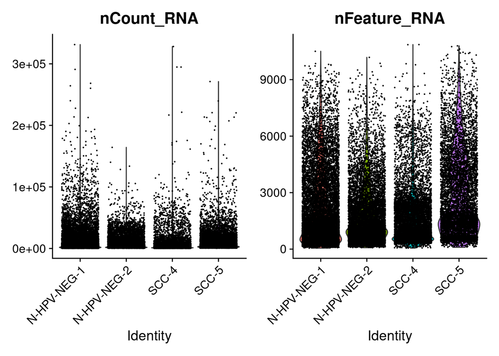

```r
DefaultAssay(seu) <- "RNA"
Seurat::Idents(seu) <- seu$orig.ident

# nCount - UMI/read counts per cell
# nFeature - Genes expressed per cell
Seurat::VlnPlot(seu, features = c("nCount_RNA",
                                  "nFeature_RNA"))
```

Plot mt, ribosomal and globin gene expression.

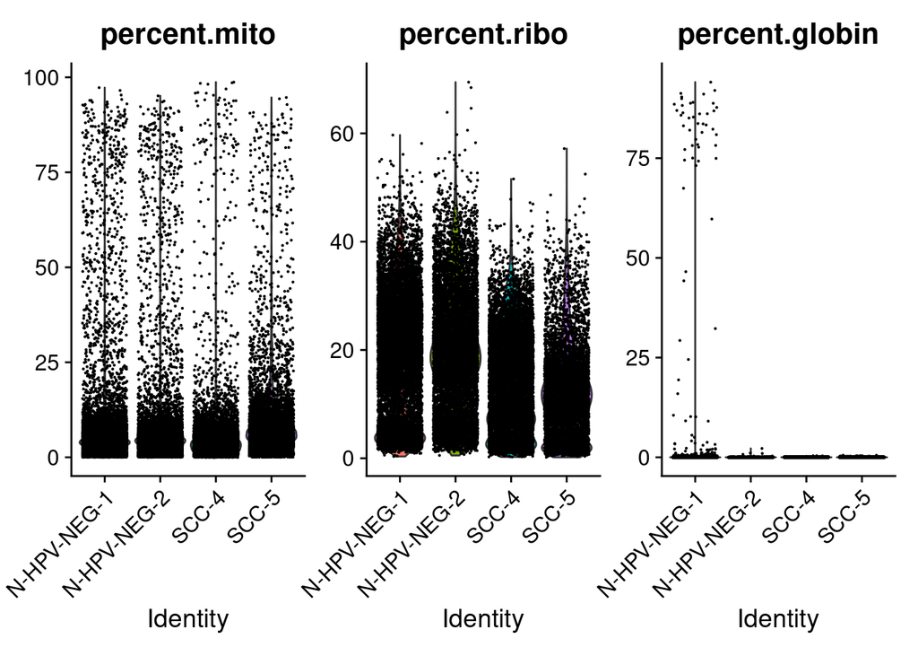

```r
# mitochondrial genes
seu <- Seurat::PercentageFeatureSet(seu,
                                    pattern = "^MT-",
                                    col.name = "percent.mito")

# ribosomal genes
seu <- Seurat::PercentageFeatureSet(seu,
                                    pattern = "^RP[SL]",
                                    col.name = "percent.ribo")

# hemoglobin genes (but not HBP)
seu <- Seurat::PercentageFeatureSet(seu,
                                    pattern = "^HB[^(P)]",
                                    col.name = "percent.globin")

Seurat::VlnPlot(seu, features = c("percent.mito",
                                  "percent.ribo",
                                  "percent.globin"))
```

## Filtering

Questions

- Is there evidence of dying cells in the dataset?
- How can we filter out dying cells?
- How does your strategy compare with what was done in the two papers?

Paper 1:

- With counts or genes outside the limits: mean value +/- 2-fold of standard deviation
- 10% mt

Paper 2:

- mt < 20%
- min features > 200
- max feature - didn’t have a threshold

Bonus questions:

- Why do you think paper 2 chose not to remove potential doublets?
- Answer: Tight distributions for n_counts and n_features -> little evidence of potential doublets
- Do you think paper 1 or paper 2 chose a better threshold for mt percentage?
- Answer: Paper 2. Based on the distribution of percent.mito, 10% seems too low. Also mt can sometimes be highly expressed in tumour cells so it’s better to be conservative.

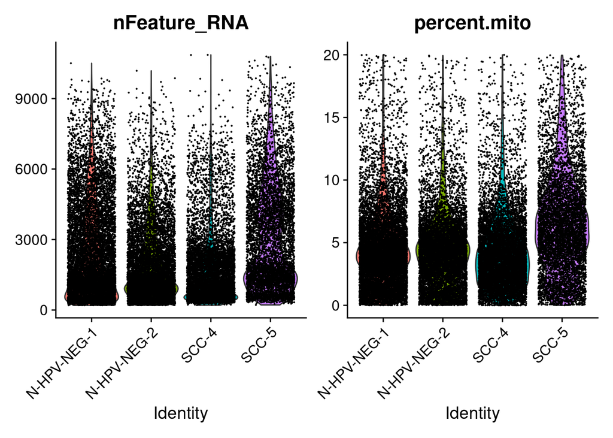

```r
# Rm low features
# Rm high mito
seu <- subset(seu, subset = nFeature_RNA > 200 &
                percent.mito < 20)
Seurat::VlnPlot(seu, features = c("nFeature_RNA",
                                  "percent.mito"))
```

```r
#saveRDS(seu,paste0(outdir,"day1.RDS"))
```

## Normalization & scaling

```r
#seu <- readRDS(paste0(outdir,"day1.RDS"))
```

```r
seu <- SCTransform(seu) #15 min
saveRDS(seu,paste0(outdir,"SCTransform.RDS"))
```

```r
seu <- readRDS(paste0(outdir,"SCTransform.RDS"))
DefaultAssay(seu) <- "SCT"
```

PCA (on the transformed SCT data)

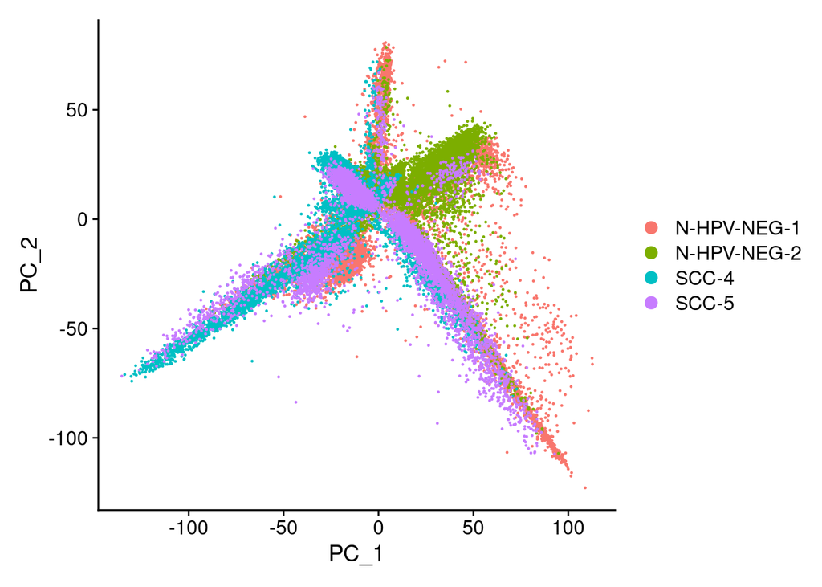

```r
seu <- Seurat::RunPCA(seu, npcs = 100)
Seurat::DimPlot(seu, reduction = "pca")
```

Question

- How many PCs would you suggest for downstream analyses?
- Answer: ~75 (based on the elbow plot)

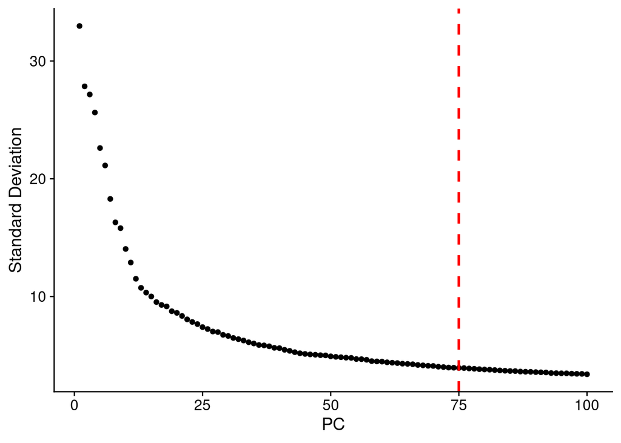

```r
Seurat::ElbowPlot(seu, ndims = 100) +
  ggplot2::geom_vline(xintercept = 75, linetype = "dashed", color = "red", linewidth = 1)
```

## UMAP

Question:

- Are there batch-efects in this dataset? How can you tell?
- Answer: In the UMAP it looks like there is clustering by sample (batch effects).

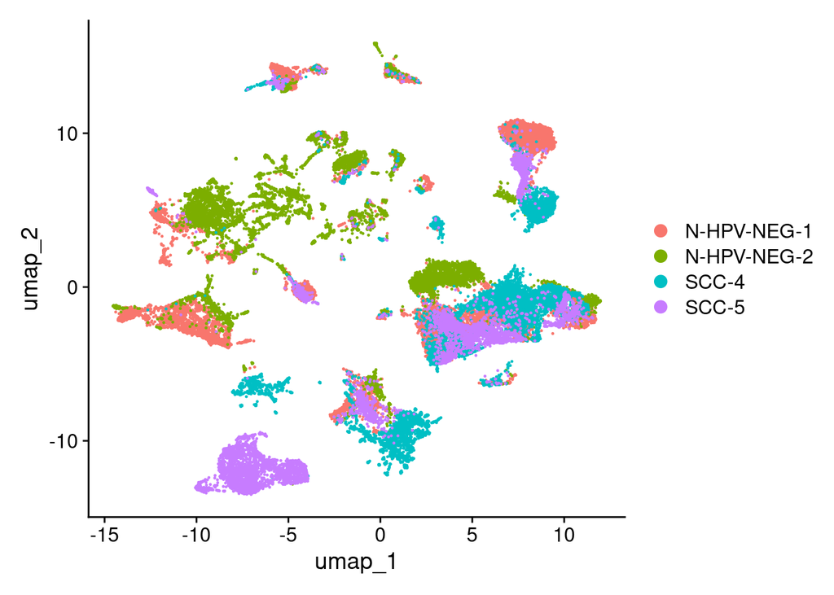

```r
seu <- Seurat::RunUMAP(seu, dims = 1:75)
Seurat::DimPlot(seu, reduction = "umap")
```

# Integration

Question:

- How can we correct for batch effects?
- Answer: Integration

```r
seu <- readRDS(paste0(outdir,"integrated.umap.clustered.RDS"))
```

```r
list <- SplitObject(seu, split.by = "orig.ident")
features <- SelectIntegrationFeatures(object.list = list)
list <- PrepSCTIntegration(object.list = list, anchor.features = features)
anchors <- FindIntegrationAnchors(object.list = list, normalization.method = "SCT",
    anchor.features = features)
seu <- IntegrateData(anchorset = anchors, normalization.method = "SCT")
```

# UMAP on integrated data

Question:

- How does the UMAP compare pre vs post integration?
- Answer: Integration has reduced the clustering by sample

```r
seu <- RunPCA(seu, verbose = FALSE, npcs = 100)
```

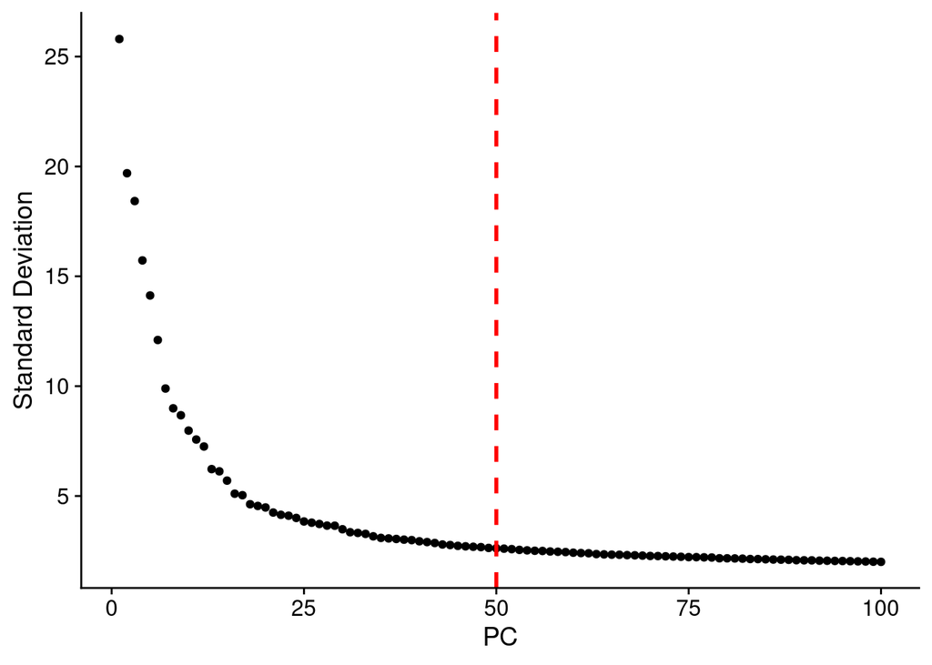

```r
Seurat::ElbowPlot(seu, ndims = 100) +
  ggplot2::geom_vline(xintercept = 50, linetype = "dashed", color = "red", linewidth = 1)
```

```r
seu <- RunUMAP(seu, reduction = "pca", dims = 1:50, verbose = FALSE)
```

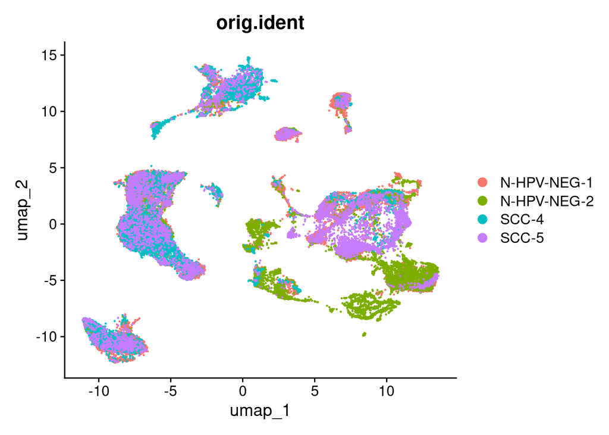

```r
Seurat::DimPlot(seu, reduction = "umap", group.by = "orig.ident")
```

# Clustering

```r
DefaultAssay(seu) <- "integrated"
seu <- FindNeighbors(seu, reduction = "pca", dims = 1:50)
seu <- Seurat::FindClusters(seu, resolution = c(0.01,0.03,0.05,0.1,0.2,0.3))
saveRDS(seu,paste0(outdir,"integrated.umap.clustered.RDS"))
```

Question

- Which clustering resolution(s) would you suggest for downstream analyses?
- Answer: Based on clustree, any of these resolutions could be appropriate. However, this also depends on the research question.

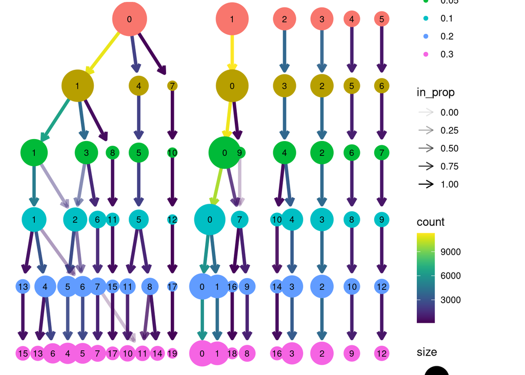

```r
clustree::clustree(seu@meta.data[,grep("integrated_snn_res.", colnames(seu@meta.data))],
                   prefix = "integrated_snn_res.")
```

```r
#p1 <- Seurat::DimPlot(seu, group.by = "integrated_snn_res.0.1")
#p2 <- Seurat::DimPlot(seu, group.by = "integrated_snn_res.0.5")
#p3 <- Seurat::DimPlot(seu, group.by = "integrated_snn_res.0.8")
#p4 <- Seurat::DimPlot(seu, group.by = "integrated_snn_res.1.")

#(p1 + p2) / (p3 + p4)
```

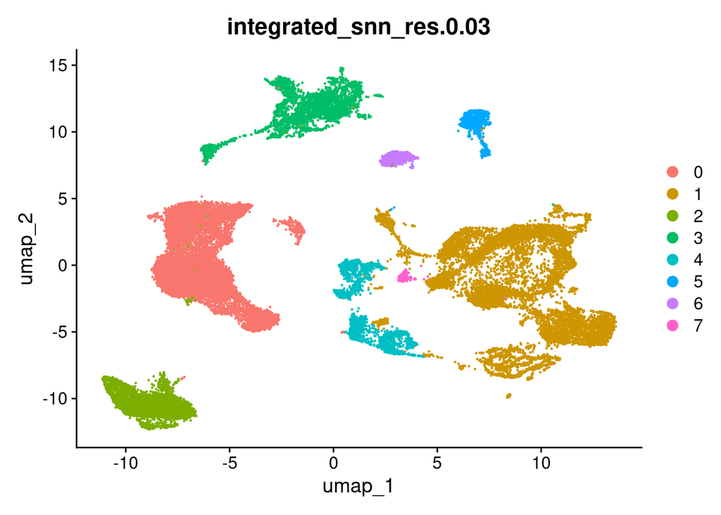

```r
Seurat::DimPlot(seu, group.by = "integrated_snn_res.0.03")
```

Select clustering

```r
seu <- Seurat::SetIdent(seu, value = "integrated_snn_res.0.03")
```

# Annotation

Question:

- Which major cell types are you expecting for this dataset?

Answer:

Looking at the papers we expect,

- Epithelial
- Immune
- Stromal (endothelial, fibroplasms, smooth muscle)

Question:

- Which marker genes could we use for annotation?
- Answer: see figure 1c. Here I chose a few cell types and markers.

```r
DefaultAssay(seu) <- "SCT"

my_marker_genes = list(
    "NK_T cells" = c('CD3E', 'CD3D','NKG7'),
    "B cells" = c('CD79A'),
    "Epithelial" = c("EPCAM","KLF5")
)
```

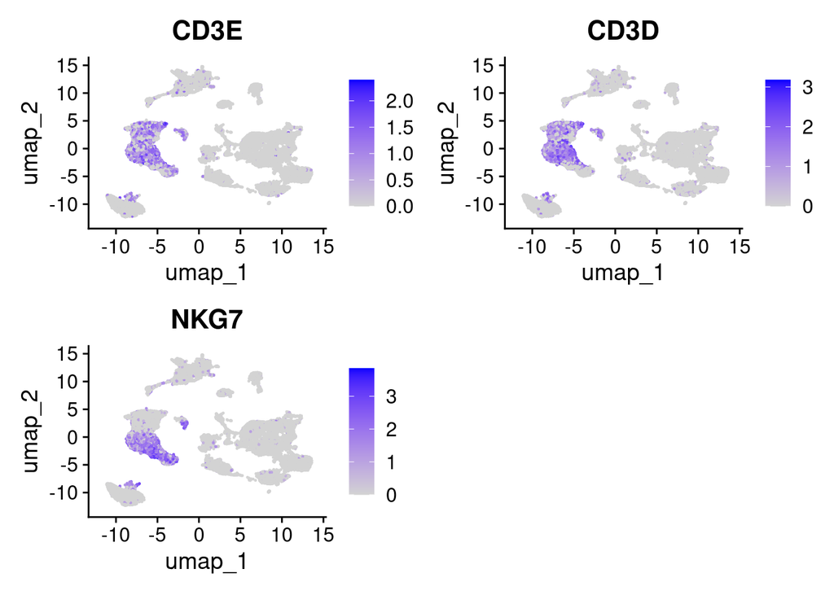

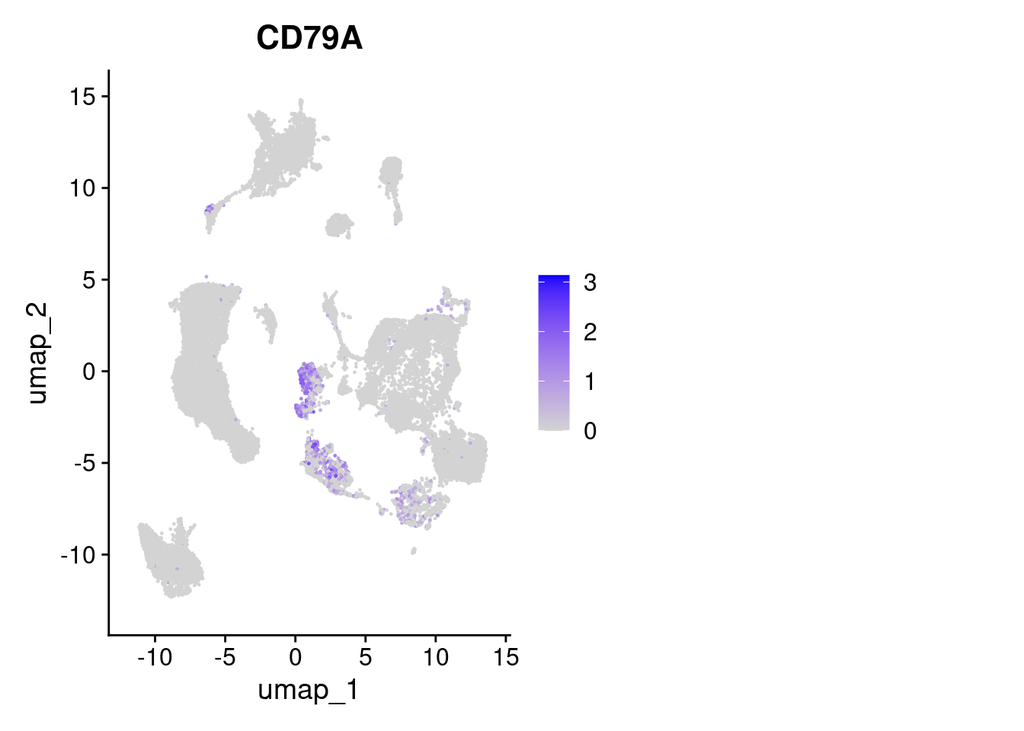

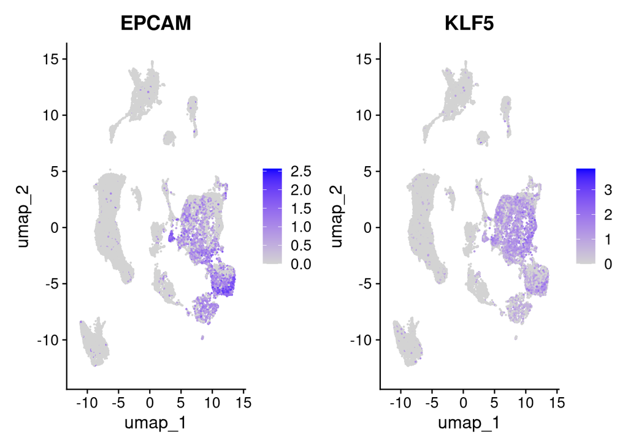

```r
for(ct in names(my_marker_genes)){
  p <- Seurat::FeaturePlot(seu, my_marker_genes[[ct]], ncol=2)
  print(p)
}
```

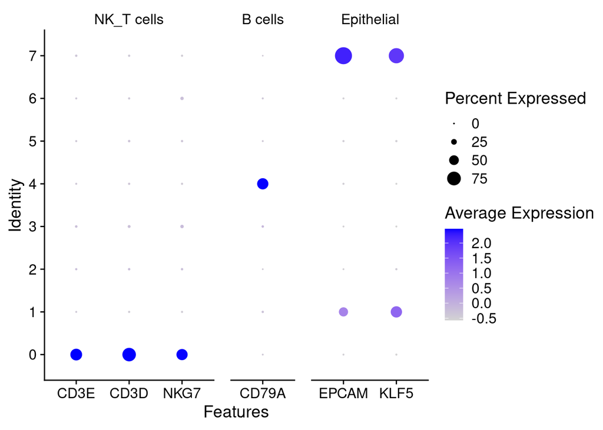

```r
p <-DotPlot(seu,
                       features =my_marker_genes,
                       group.by = "integrated_snn_res.0.03"
            )

p
```

Question:

- Which clusters can you clearly identify using these markers genes?

Answer:

- Cluster 0 - NK/T cells
- Cluster 4 - B cells
- Cluster 1 & 7 - Epithelial

Bonus questions:

- If we didn’t have such a list of marker genes, which other techniques could we try?
- Answer 1: Seurat::FindMarkers to idenfiy DE genes per cluster (compare these to the literature)
- Answer 2: SingleR for automated annotation from a reference
- How do these compare to manual annotation?